# Explore CNV distributions of reference cells: SCPCP000015

Stephanie J. Spielman

2025-06-03

## Introduction

We have previously observed that the reference cell CNV distributions in pooled references may overlap with tumor CNV distributions. This notebook aims to explore the extent of this trend for `SCPCP000015`, as well as compare CNV distributions among cell groups for all libraries.

## Setup

```r
options(readr.show_col_types = FALSE)
suppressPackageStartupMessages({
  library(ggplot2)
  library(SingleCellExperiment)
})
theme_set(theme_bw())
```

### Functions

This function prepares a table of `inferCNV` results by creating a `total_cnv_per_cell` column to summarize CNVs per cell.

```r
prepare_cnv_df <- function(infercnv_tsv) {
  infercnv_df <- readr::read_tsv(infercnv_tsv)

  infercnv_metadata_df <- infercnv_df |>
    dplyr::select(
      -starts_with("has_"),
      -starts_with("proportion_"),
      -starts_with("top_")
    ) |>
    dplyr::mutate(cell_group = stringr::str_split_i(subcluster, "_", 1))

  infercnv_df |>
    tidyr::pivot_longer(
      starts_with("has_cnv_"),
      names_to = "chr",
      values_to = "cnv"
    ) |>
    # sum all values for each
    dplyr::group_by(cell_id) |>
    dplyr::summarize(total_cnv_per_cell = sum(cnv)) |>
    dplyr::ungroup() |>
    # bring back metadata
    dplyr::inner_join(
      infercnv_metadata_df,
      by = "cell_id"
    )
}
```

This function plots ridge plots of total CNV values across cell groupings for a given normal reference.

```r
plot_cnv_distributions <- function(reference_name, df) {
  filtered_df <- df |>
    dplyr::filter(normal_reference == reference_name)

  ggplot(filtered_df) +
    aes(x = total_cnv_per_cell, y = label, fill = label) +
    ggridges::geom_density_ridges2(scale = 0.9) +
    facet_wrap(vars(infercnv_library_id)) +
    theme(legend.position = "none") +
    ggtitle(reference_name)
}
```

### Paths

#### Base directories

```r
# The base path for the OpenScPCA repository, found by its (hidden) .git directory
repository_base <- rprojroot::find_root(rprojroot::is_git_root)

module_dir <- file.path(repository_base, "analyses", "infercnv-consensus-cell-type")
result_dir <- file.path(module_dir, "results", "SCPCP000015") # organized as sample/reference/infercnv results
ewings_dir <- file.path(repository_base, "data", "current", "results", "cell-type-ewings", "SCPCP000015")
```

#### Input files

```r
# inferCNV output files
infercnv_files <- list.files(
  path = result_dir,
  pattern = "_cnv-metadata\\.tsv",
  recursive = TRUE,
  full.names = TRUE
) |>
  # remove any containing "internal"; we only want pooled
  purrr::discard(\(x) {
    stringr::str_detect(x, "internal")
  }) |>
  # name by "library-reference"
  purrr::set_names(\(x) {
    library_id <- stringr::str_split_i(basename(x), "_", 1)
  })


# ewing module cell types
celltype_files <- list.files(
  ewings_dir,
  pattern = "_ewing-celltype-assignments\\.tsv",
  recursive = TRUE,
  full.names = TRUE
) |>
  # name by library id
  purrr::set_names(\(x) {
    stringr::str_split_i(basename(x), "_", 1)
  })
```

### Read input files

We’ll first read in the cell type annotations:

```r
celltype_df <- celltype_files |>
  purrr::map(readr::read_tsv) |>
  purrr::list_rbind(names_to = "library_id") |>
  dplyr::mutate(cell_id = glue::glue("{library_id}-{barcodes}")) |>
  dplyr::select(cell_id, consensus_annotation, ewing_annotation)
```

Now, we’ll read in the `inferCNV` results:

```r
infercnv_df <- infercnv_files |>
  purrr::map(prepare_cnv_df) |>
  purrr::list_rbind(names_to = "infercnv_library_id") |>
  dplyr::inner_join(celltype_df, by = "cell_id") |>
  # condense labels for cell type groupings
  dplyr::mutate(
    label = ifelse(
      stringr::str_detect(ewing_annotation, "tumor"),
      "tumor",
      cell_group
    ),
    label = forcats::fct_relevel(label, "unknown", "tumor", "reference")
  )
```

## Analysis

We’ll first visualize the total CNV distributions for each inference for each grouping of cells:

- `unknown`: query cells
- `tumor`: query cells labeled “tumor” by `cell-type-ewings`
- `reference`: cells in the normal reference

We show a plot faceted by library `inferCNV` was run on for each of the three pooled references explored.

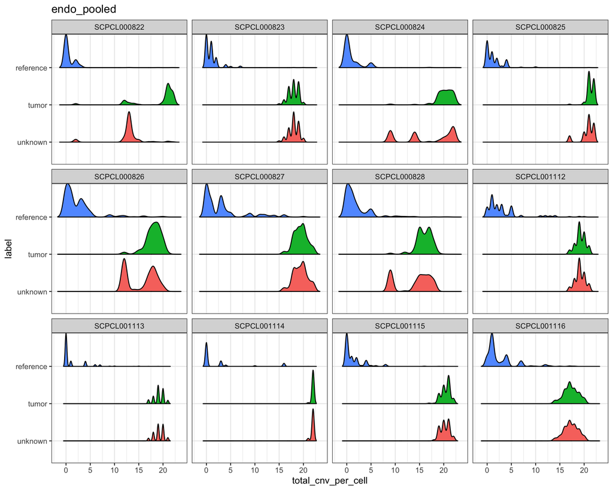

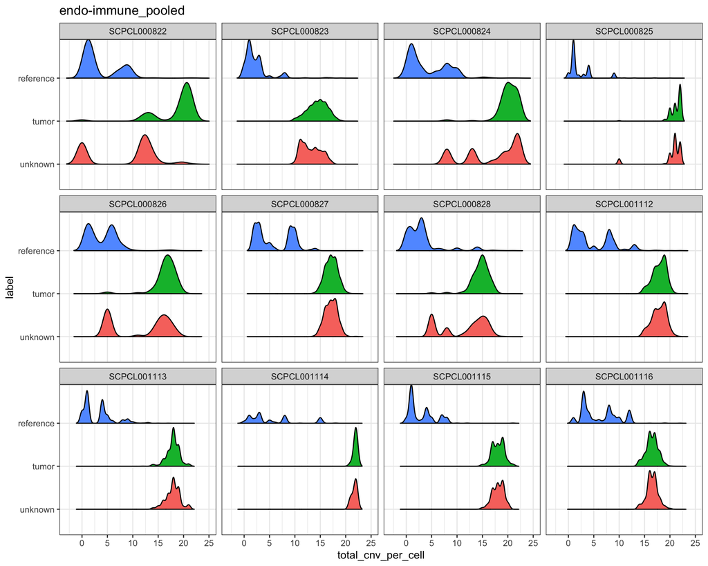

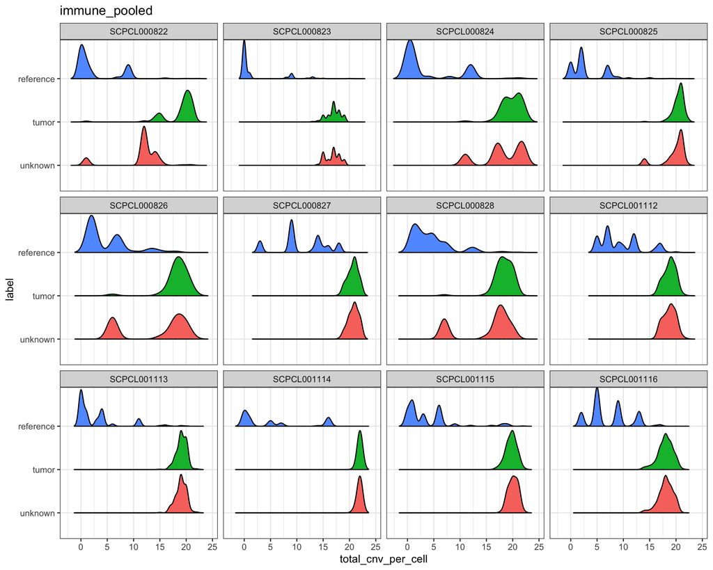

```r
unique(infercnv_df$normal_reference) |>
  purrr::map(plot_cnv_distributions, infercnv_df)
```

- The `endo` reference cell CNV distributions generally do not overlap with tumor cell CNV distributions.
- The `endo-immune` and `immune` reference cell CNV distributions do have a wider spread but do not *substantially* overlap with the tumor cell CNV distributions.

Let’s look more closely at the `immune_pooled` reference to see if any particular libraries might be driving a (minor) trend. For each inference with the `immune_pooled` reference, we’ll find the 25% top reference cells with the highest CNVs. Do these cells tend to be from a particular library?

The barplot below shows for each `inferCNV` inference with the `immune_pooled` reference, the proportion of reference cells contributed by each of the five given libraries.

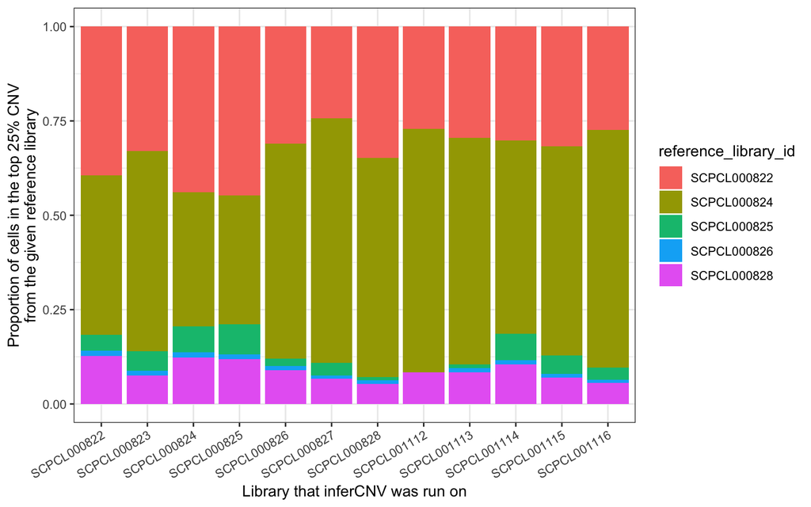

```r
top25_df <- infercnv_df |>
  dplyr::filter(
    normal_reference == "immune_pooled",
    cell_group == "reference"
  ) |>
  tidyr::separate(cell_id, into = c("reference_library_id", "barcode"), sep = "-") |>
  # keep only the top 25% of cells
  dplyr::group_by(infercnv_library_id) |>
  dplyr::slice_max(total_cnv_per_cell, prop = 0.25) |>
  dplyr::ungroup()

ggplot(top25_df) +
  aes(x = infercnv_library_id, fill = reference_library_id) +
  geom_bar(position = "fill") +
  labs(
    x = "Library that inferCNV was run on",
    y = "Proportion of cells in the top 25% CNV\nfrom the given reference library"
  ) +
  theme(axis.text.x = element_text(angle = 30, hjust = 1))
```

## Conclusions

It does not seem that reference cell CNV distributions are problematically overlapping with tumor CNV distributions now that references were updated to generate these re-processed results. Overall, the `endo_pooled` reference appears to give the most distinct CNV distributions between reference and tumor cells.